# RANS from DNS

Our goal here, in general, is to find new valid equations that describe fluid flow. We will try to find new closures for the steady RANS equations based on direct numerical simulation (DNS) of a boundary layer.

## Steady RANS equations

$$ (\vec{U} \cdot \nabla) \vec{U} + \frac{1}{\rho} \nabla P - \nu \nabla^2 \vec{U} = - \frac{1}{\rho} \nabla \cdot \mathbf{R}, $$

where in this case $\mathbf{R}$ is the Reynolds stress tensor.

In order to be rank-consistent, terms that "make up" $- \frac{1}{\rho} \nabla \cdot \mathbf{R}$ can be one of:

- Gradient of a scalar (e.g., pressure gradient)
- Laplacian of a vector (e.g., viscous stress)
- Inner product of a tensor with a vector
- A vector multiplied by a scalar (e.g., advection)

Some ideas for what the Reynolds stress residual term could be:

$$ - \frac{1}{\rho} \nabla \cdot \mathbf{R} = a \nabla K + b \left( \nabla \vec{U} \cdot \nabla P \right) + c \nabla \cdot \vec{U} \nabla P $$

## Algorithm

1. Pick terms (in addition to non-Reynolds stress Navier--Stokes terms).
2. Create a random list of points in space that is at least as large as the number of terms.
3. At each point, acquire all data for all terms for all times.
4. Average data at each point for all times.
5. Solve for coefficients using a linear model.

```python
%load_ext autoreload
%autoreload 2

import seaborn
seaborn.set_theme()
```

## Using data from pyJHTDB

1. Pick a bunch of points randomly throughout the domain, at least more than the number of terms we want to test.
2. Add points in each direction for computing spatial derivatives.
3. Get $\vec{u}$, $p$, and their gradients for all time at all points in the list.
4. Calculate terms based on mean values.
5. Use a regression model to determine coefficients on each term.
6. Repeat this process to ensure the coefficients don't change?
7. Run a RANS simulation with this new model and check the results against the mean profiles.

```python
from pypkg.paths import p
import pandas as pd

df = pd.read_hdf(p("data/jhtdb-transitional-bl/all-stats.h5"), key="data")
```

```python
from pypkg.paths import p
# Exact gradients from the JHTDB web service, sampled at 100 points.
#
# NOT the finite differences in all-stats.h5, which carry a _fd suffix. These
# live in their own file because they are the only source of the spanwise
# derivatives -- dwdz cannot be obtained from the 2-D time-averaged profiles at
# all -- and because fetching them needs a JHTDB token, so they must not sit on
# the pipeline's critical path. See scripts/standalone/fetch-jhtdb-gradients.py.
#
# Joined to the mean fields at the same (x, y) so the momentum-balance checks
# below can use exact gradients and mean velocities together.
import pandas as pd

# The two frames share the (x, y) index and have no overlapping column names
# -- all-stats labels its finite differences with a _fd suffix precisely so
# they cannot be confused with these exact ones -- so a plain join is safe.
grad = pd.read_hdf(
    p("data/jhtdb-transitional-bl/sampled-gradients.h5"), key="data"
).join(df)

# Continuity: the three normal strains should sum to zero.
div = grad["dudx"] + grad["dvdy"] + grad["dwdz"]
div.describe()
```

```
count    100.000000
mean       0.000020
std        0.000220
min       -0.000722
25%       -0.000015
50%        0.000001
75%        0.000043
max        0.000913
dtype: float64
```

The check above gives us an idea on how accurate these gradient calculations are.

```python
df.columns
```

```
Index(['p', 'pp', 'u', 'up', 'uu', 'uv', 'uw', 'v', 'vp', 'vv', 'vw', 'w',
       'wp', 'ww', 'dpdx_fd', 'duudx_fd', 'duvdx_fd', 'duvdy_fd', 'dudx_fd',
       'dudy_fd', 'd2udx2_fd', 'd2udy2_fd', 'dpdy_fd'],
      dtype='str')
```

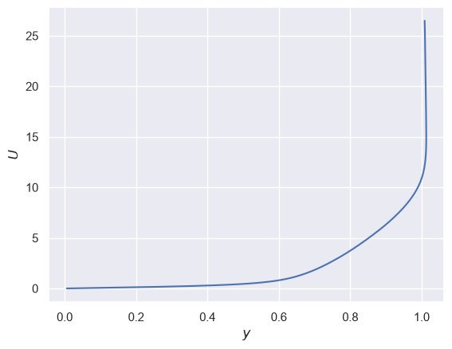

```python
ax = (
    df.loc[df.index.get_level_values("x")[-1000]]
    .reset_index()
    .plot(x="u", y="y", legend=False, ylabel="$U$", xlabel="$y$")
)
```

```python
# Check the momentum equation
from pypkg import nu, rho

momx_no_res = (
    grad.u * grad.dudx
    + grad.v * grad.dudy
    + grad.w * grad.dudz
    + (1 / rho) * grad.dpdx
    - nu * (grad.d2udx2 + grad.d2udy2 + grad.d2udz2)
)

momx = momx_no_res + (grad.duudx_fd + grad.duvdy_fd)

momx.dropna().describe()
```

```
count    100.000000
mean       0.000104
std        0.000464
min       -0.001651
25%       -0.000033
50%        0.000030
75%        0.000388
max        0.001416
dtype: float64
```

## Check the $y$-component of the momentum equation

$$ U \frac{\partial V}{\partial x} + V \frac{\partial V}{\partial y} = - \frac{1}{\rho} \frac{\partial P}{\partial y} + \nu \left( \frac{\partial^2 V}{\partial x^2} + \frac{\partial^2 V}{\partial y^2} \right) $$

$$ - \left( \frac{\partial \overline{u'v'}}{\partial x} + \frac{\partial \overline{v'v'}}{\partial y} \right ) $$

```python
# Check the y-component of the momentum equation
from pypkg import nu, rho

momy_no_res = (
    grad.u * grad.dvdx
    + grad.v * grad.dvdy
    + (1 / rho) * grad.dpdy
    - nu * (grad.d2vdx2 + grad.d2vdy2)
)

momy = momy_no_res + (grad.duvdx_fd + grad.duvdy_fd)

momy_no_res.dropna().describe()
```

```
count    100.000000
mean      -0.000545
std        0.001150
min       -0.004019
25%       -0.000802
50%       -0.000007
75%        0.000116
max        0.000982
dtype: float64
```

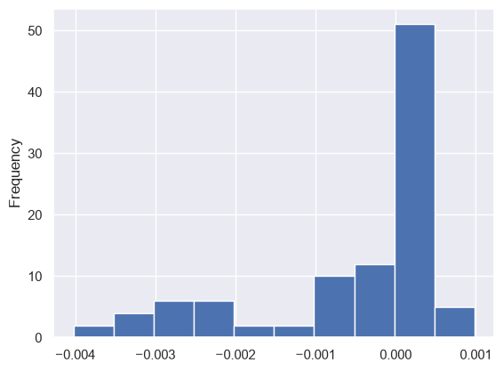

```python
momy_no_res.plot.hist()
```

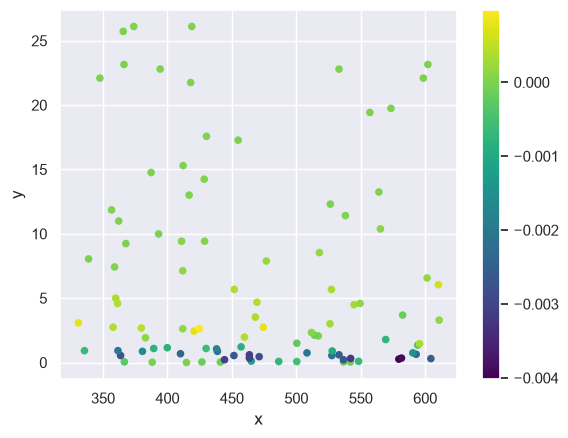

```python
# Let's see how large the Reynold's stress residual is at different locations
df1 = grad.dropna().reset_index()
df1.plot.scatter(
    x="x", y="y", c=momy_no_res.dropna().values, cmap="viridis"
)
```

## Compute terms from averaged data

```python
from pypkg.paths import p
# Let's check the time-averaged profiles
import pandas as pd
import h5py
import numpy as np


def read_profiles():
    """Read profile data from JHTDB HDF5 file, and assemble into a dictionary
    of NumPy arrays.
    """
    with h5py.File(
        p("data/jhtdb-transitional-bl/time-ave-profiles.h5"), "r"
    ) as f:
        data = {}
        for k in f.keys():
            kn = k.split("_")[0]
            if kn.endswith("m"):
                kn = kn[:-1]
            data[kn] = f[k][()]
    # Calculate some finite difference gradients
    dx = np.gradient(data["x"])
    dy = np.reshape(np.gradient(data["y"]), (224, 1))
    # dz = np.gradient(data["z"])
    # Correct fluctuation terms according to README
    # >uum is the time-averaged of u*u (not u'*u', where u'=u-um).
    # >So time-averaged of u'*u'=uum-um*um. Same for other quantities.
    for dim1 in ("u", "v", "w"):
        for dim2 in ("u", "v", "w"):
            if f"{dim1}{dim2}" in data:
                data[f"{dim1}{dim2}"] = (
                    data[f"{dim1}{dim2}"] - data[dim1] * data[dim2]
                )
    # Calculate gradients
    data["dpdx"] = np.gradient(data["p"], axis=1) / dx
    data["duudx"] = np.gradient(data["uu"], axis=1) / dx
    data["duvdx"] = np.gradient(data["uv"], axis=1) / dx
    data["duvdy"] = np.gradient(data["uv"], axis=0) / dy
    data["dvvdy"] = np.gradient(data["vv"], axis=0) / dy
    data["dudx"] = np.gradient(data["u"], axis=1) / dx
    data["dudy"] = np.gradient(data["u"], axis=0) / dy
    data["dvdx"] = np.gradient(data["v"], axis=1) / dx
    data["dvdy"] = np.gradient(data["v"], axis=0) / dy
    data["d2udx2"] = np.gradient(data["dudx"], axis=1) / dx
    data["d2udy2"] = np.gradient(data["dudy"], axis=0) / dy
    data["d2vdx2"] = np.gradient(data["dvdx"], axis=1) / dx
    data["d2vdy2"] = np.gradient(data["dvdy"], axis=0) / dy
    data["dpdx"] = np.gradient(data["p"], axis=1) / dx
    data["dpdy"] = np.gradient(data["p"], axis=0) / dy
    # data["dwdz"] = np.gradient(data["w"], axis=1) / dz
    return data


data = read_profiles()
```

## Plot RANS simulation versus averaged DNS data

```python
from pypkg.paths import p
import plotly.express as px
import plotly
import glob
from IPython.display import display, HTML

# Workaround to show LaTeX labels
plotly.offline.init_notebook_mode()
display(
    HTML(
        '<script type="text/javascript" async '
        'src="https://cdnjs.cloudflare.com/ajax/libs/mathjax/'
        '2.7.1/MathJax.js?config=TeX-MML-AM_SVG"></script>'
    )
)

fig = px.line(x=data["u"][:, 1500], y=data["y"], height=800).update_traces(
    line_color="green", line_dash="dash", name="DNS"
)

turbulence_model = "k-epsilon"

for ny in [15, 20, 30, 40, 60]:
    fpaths = glob.glob(
        p(f"sim/cases/{turbulence_model}-ny-{ny}/postProcessing/sample/*/x906.8_*.csv")
    )
    assert len(fpaths) == 1
    df2 = pd.read_csv(fpaths[0])
    fig2 = df2.plot(x="U_0", y="y", backend="plotly").update_traces(
        name=f"$N_y = {ny}$"
    )
    fig = fig.add_trace(fig2.data[0])
    fig.data[0].name = "DNS"
    fig.data[1].name = r"$k$--$\epsilon$"
fig = fig.update_layout(
    showlegend=True, xaxis=dict(title=r"$U$"), yaxis=dict(title="$y$")
)
fig.show()
```

[interactive chart not shown]

```python
from pypkg.paths import p
import plotly.express as px
import plotly
import glob
from IPython.display import display, HTML

# Workaround to show LaTeX labels
plotly.offline.init_notebook_mode()
display(
    HTML(
        '<script type="text/javascript" async '
        'src="https://cdnjs.cloudflare.com/ajax/libs/mathjax/'
        '2.7.1/MathJax.js?config=TeX-MML-AM_SVG"></script>'
    )
)

fig = px.line(x=data["u"][:, 1500], y=data["y"], height=800).update_traces(
    line_color="green", line_dash="dash", name="DNS"
)

turbulence_model = "laminar"

for ny in [40]:
    fpaths = glob.glob(
        p(f"sim/cases/{turbulence_model}-ny-{ny}/postProcessing/sample/*/x906.8_*.csv")
    )
    assert len(fpaths) == 1
    df2 = pd.read_csv(fpaths[0])
    fig2 = df2.plot(x="U_0", y="y", backend="plotly").update_traces(
        name=f"$N_y = {ny}$"
    )
    fig = fig.add_trace(fig2.data[0])
    fig.data[0].name = "DNS"
    fig.data[1].name = r"$k$--$\epsilon$"
fig = fig.update_layout(
    showlegend=True, xaxis=dict(title=r"$U$"), yaxis=dict(title="$y$")
)
fig.show()
```

[interactive chart not shown]

```python
from pypkg.paths import p
import plotly.express as px
import plotly
import glob
from IPython.display import display, HTML

# Workaround to show LaTeX labels
plotly.offline.init_notebook_mode()
display(
    HTML(
        '<script type="text/javascript" async '
        'src="https://cdnjs.cloudflare.com/ajax/libs/mathjax/'
        '2.7.1/MathJax.js?config=TeX-MML-AM_SVG"></script>'
    )
)

fig = px.line(x=data["u"][:, 1500], y=data["y"], height=800).update_traces(
    line_color="green", line_dash="dash", name="DNS"
)

turbulence_model = "new"

for ny in [40]:
    fpaths = glob.glob(
        p(f"sim/cases/{turbulence_model}-ny-{ny}/postProcessing/sample/*/x906.8_*.csv")
    )
    assert len(fpaths) == 1
    df2 = pd.read_csv(fpaths[0])
    fig2 = df2.plot(x="U_0", y="y", backend="plotly").update_traces(
        name=f"$N_y = {ny}$"
    )
    fig = fig.add_trace(fig2.data[0])
    fig.data[0].name = "DNS"
    fig.data[1].name = r"$k$--$\epsilon$"
fig = fig.update_layout(
    showlegend=True, xaxis=dict(title=r"$U$"), yaxis=dict(title="$y$")
)
fig.show()
```

[interactive chart not shown]

```python
import plotly.express as px

fig = (
    px.line(x=-nu * data["d2udy2"][:, 1500], y=data["y"], height=800)
    .update_traces(line_color="green", line_dash="dash", name="DNS")
    .show()
)
```

[interactive chart not shown]

```python
import plotly.express as px

fig = (
    px.line(x=1 / rho * data["dpdx"][:, 1500], y=data["y"], height=800)
    .update_traces(line_color="green", line_dash="dash", name="DNS")
    .show()
)
```

[interactive chart not shown]

```python
import plotly.express as px

fig = (
    px.line(x=data["dudy"][:, 1500], y=data["y"], height=800)
    .update_traces(line_color="green", line_dash="dash", name="DNS")
    .show()
)
```

[interactive chart not shown]

```python
import plotly.express as px

fig = (
    px.line(x=data["dudy"][:, 1500]**(3)*data["y"], y=data["y"], height=800)
    .update_traces(line_color="green", line_dash="dash", name="DNS")
    .show()
)
```

[interactive chart not shown]

## Detect coefficients of new terms

```python
# Compute a bunch of quantities and add to the data
data = read_profiles()
dx = np.gradient(data["x"])
dy = np.reshape(np.gradient(data["y"]), (224, 1))
# Advection of momentum
data["advection_x"] = data["u"] * data["dudx"] + data["v"] * data["dudy"]
data["advection_y"] = data["u"] * data["dvdx"] + data["v"] * data["dvdy"]
# Mean kinetic energy
data["k"] = 0.5 * (data["u"] ** 2 + data["v"] ** 2)
# Squared gradients
data["dudx2"] = data["dudx"] ** 2
data["dudy2"] = data["dudy"] ** 2
# Gradients of squares
data["du2dy"] = np.gradient(data["u"] ** 2, axis=0) / dy
data["dv2dy"] = np.gradient(data["v"] ** 2, axis=0) / dy
data["du2dx"] = np.gradient(data["u"] ** 2, axis=1) / dx
data["dv2dx"] = np.gradient(data["v"] ** 2, axis=1) / dx
# Mean kinetic energy gradient
data["dkdy"] = np.gradient(data["k"], axis=0) / dy
data["dkdx"] = np.gradient(data["k"], axis=1) / dx
data["d2kdy2"] = np.gradient(data["dkdy"], axis=0) / dy
data["d2kdx2"] = np.gradient(data["dkdx"], axis=1) / dx
# Gradients multiplied by each other
# Gradients multiplied by mean values
# Misc terms
data["u2dudy"] = data["u"] ** 2 * data["dudy"]
data["udpdx"] = data["u"] * data["dpdx"]
data["dpdx2"] = data["dpdx"] ** 2
data["dpdy2"] = data["dpdy"] ** 2
data["d2pdx2"] = np.gradient(data["dpdx"], axis=1) / dx
data["d2pdy2"] = np.gradient(data["dpdy"], axis=0) / dy
data["dp2dx"] = np.gradient(data["p"] ** 2, axis=1) / dx
data["dp2dy"] = np.gradient(data["p"] ** 2, axis=0) / dy
data["vdpdy"] = data["v"] * data["dpdy"]
data["duudy"] = np.gradient(data["uu"], axis=0) / dy
data["magsqrgradp"] = data["dpdx"] ** 2 + data["dpdy"] ** 2
data["laplacianp"] = data["d2pdx2"] + data["d2pdy2"]
data["laplacianvel_x"] = data["d2udx2"] + data["d2udy2"]
data["laplacianvel_y"] = data["d2vdx2"] + data["d2vdy2"]
data["vorticityz"] = data["dvdx"] - data["dudy"]
data["gradmagvort_x"] = np.gradient(data["vorticityz"], axis=1) / dx
data["gradmagvort_y"] = np.gradient(data["vorticityz"], axis=0) / dy
data["pu"] = data["p"] * data["u"]
data["pv"] = data["p"] * data["v"]
data["divvelpgrad_x"] = data["u"] * data["d2pdx2"] + data["u"] * data["d2pdy2"]
data["divvelpgrad_y"] = data["v"] * data["d2pdx2"] + data["v"] * data["d2pdy2"]
data["duvdy"] = np.gradient(data["uv"], axis=0) / dy
data["duvdx"] = np.gradient(data["uv"], axis=1) / dx
data["divuu_x"] = data["du2dx"] + data["duvdy"]
data["divuu_y"] = data["duvdx"] + data["dv2dy"]
data["magsqru"] = data["u"] ** 2 + data["v"] ** 2
data["pbymagsqru"] = data["p"] / data["magsqru"]
data["gradpbymagsqru_x"] = np.gradient(data["pbymagsqru"], axis=1) / dx
data["gradpbymagsqru_y"] = np.gradient(data["pbymagsqru"], axis=0) / dy
data["divp"] = data["dpdx"] + data["dpdy"]
data["ddivpdx"] = np.gradient(data["divp"], axis=1) / dx
data["ddivpdy"] = np.gradient(data["divp"], axis=0) / dy
data["gradugradpx"] = data["dudx"] * data["dpdx"] + data["dudy"] * data["dpdy"]
data["gradugradpy"] = data["dvdx"] * data["dpdx"] + data["dvdy"] * data["dpdy"]
# Reynolds stress terms
data["restress_x"] = data["duudx"] + data["duvdy"]
data["restress_y"] = data["duvdx"] + data["dvvdy"]
```

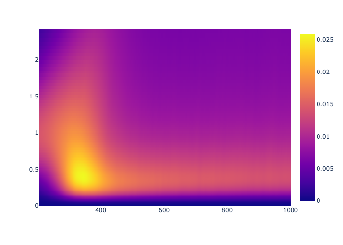

```python
from pypkg.plotting import plot_heatmap

plot_heatmap(
    data["uu"],
    data,
    interactive=False,
    ix_min=600,
    iy_max=100,
)
```

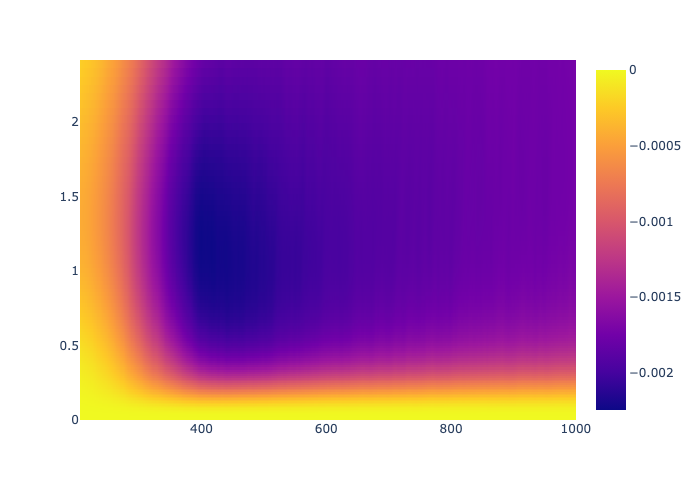

```python
from pypkg.plotting import plot_heatmap

plot_heatmap(
    data["uv"],
    data,
    interactive=False,
    ix_min=600,
    iy_max=100,
)
```

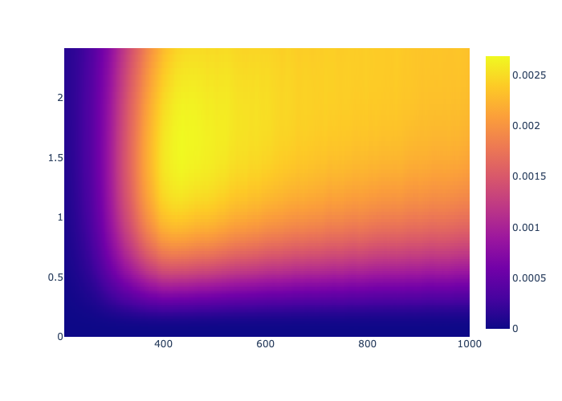

```python
from pypkg.plotting import plot_heatmap

plot_heatmap(
    data["vv"],
    data,
    interactive=False,
    ix_min=600,
    iy_max=100,
)
```

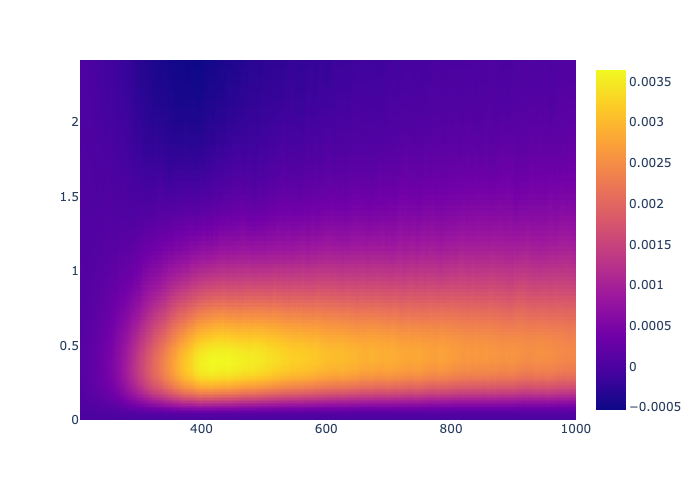

```python
plot_heatmap(
    data["restress_y"],
    data,
    interactive=False,
    ix_min=600,
    iy_max=100,
)
```

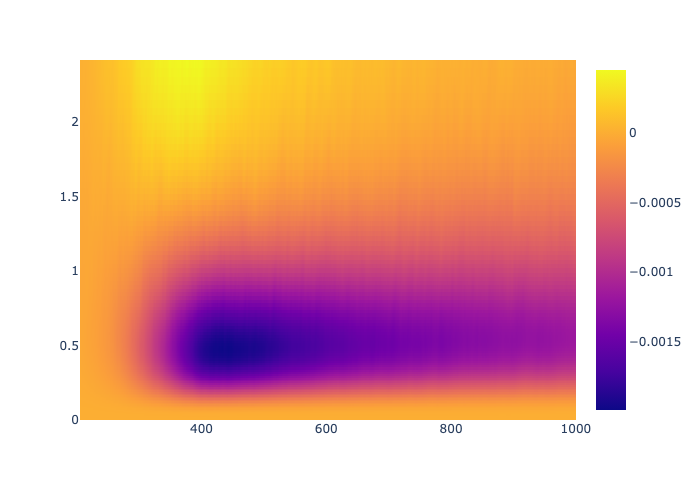

```python
plot_heatmap(
    data["u"] * data["dpdy"],
    data,
    interactive=False,
    ix_min=600,
    iy_max=100,
)
```

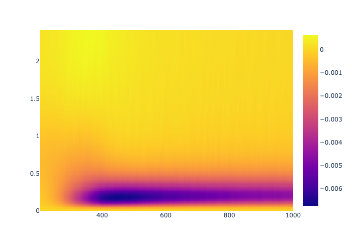

```python
plot_heatmap(
    data["duvdy"],
    data,
    interactive=False,
    ix_min=600,
    iy_max=100,
)
```

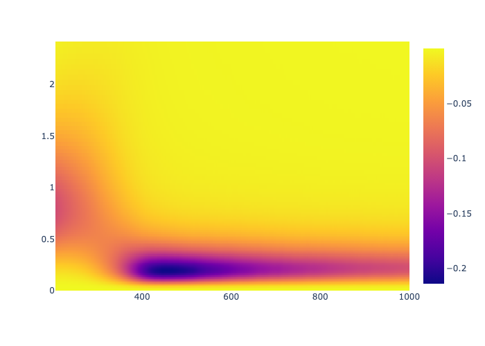

```python
plot_heatmap(
    -(data["dkdx"] + data["dkdy"])**2,
    data,
    interactive=False,
    ix_min=600,
    iy_max=100,
)
```

```python
from sklearn.linear_model import LinearRegression

terms = [
    # Mean kinetic energy gradients
    "dkdx",
    # "dkdy",
    # Squared velocity gradients
    # "dudx2",
    # "dudy2",
    # Gradients of squared velocity
    # "du2dx",
    # "du2dy",
    # "dv2dx",
    # "dv2dy",
    # Cross-stream pressure gradient
    # "dpdy",
    # Misc
    # "u2dudy",
    # "udpdx",
    # "dpdx2",
    "dpdy2",
    "d2pdx2",
    "d2pdy2",
    # "dp2dx",
    # "dpdx",
]

# Form our X matrix
X = np.array([data[term].flatten() for term in terms]).transpose()

# Form our y vector, which is simply the x-component of the 2-D RANS equations
# with no Reynolds stresses
y = (
    data["u"] * data["dudx"]
    + data["v"] * data["dudy"]
    + 1 / rho * data["dpdx"]
    - nu * (data["d2udx2"] + data["d2udy2"])
).flatten()

print("Dataset size:", len(y))

reg = LinearRegression(fit_intercept=False).fit(X, y)
print("Score:", reg.score(X, y))
print()
for term, coeff in zip(terms, reg.coef_):
    print(term, coeff)
```

```
Dataset size: 743680
Score: 0.9073310033825843

dkdx 0.1961596512077166
dpdy2 320.97035432492834
d2pdx2 -13.26059400516657
d2pdy2 -0.29480986717341867
```

```python
from sklearn.linear_model import LinearRegression

terms = [
    # Mean kinetic energy gradients
    # "dkdx",
    "dkdy",
    # Squared velocity gradients
    # "dudx2",
    # "dudy2",
    # Gradients of squared velocity
    # "du2dx",
    # "du2dy",
    # "dv2dx",
    # "dv2dy",
    # Streamwise pressure gradient
    # "dpdx",
    # Misc
    # "u2dudy",
    # "udpdx",
    "dpdx2",
    "dpdy2",
    # "d2pdx2",
    "d2pdx2",
    "d2pdy2",
    # "dp2dx",
    # "dpdy",
]

# Form our X matrix
X = np.array([data[term].flatten() for term in terms]).transpose()

# Form our y vector, which is simply the x-component of the 2-D RANS equations
# with no Reynolds stresses
y = (
    data["u"] * data["dvdx"]
    + data["v"] * data["dvdy"]
    + 1 / rho * data["dpdy"]
    - nu * (data["d2vdx2"] + data["d2vdy2"])
).flatten()
print("Dataset size:", len(y))

reg = LinearRegression(fit_intercept=False).fit(X, y)
print("Score:", reg.score(X, y))
print()
for term, coeff in zip(terms, reg.coef_):
    print(term, coeff)
```

```
Dataset size: 743680
Score: 0.9014080606613647

dkdy -0.0007406508576428812
dpdx2 0.09898646920912367
dpdy2 -343.99875912825746
d2pdx2 -4.626051761837426
d2pdy2 0.009297158284932132
```

```python
from sklearn.linear_model import LinearRegression

# Now we need to solve for both components at the same time so we use the same
# parameters for each
terms = [
    # "dkd{dim}",
    "gradugradp{dim}",
    # "restress_{dim}",  # Should be the most important term, but cheating
    "divuu_{dim}",
    "divvelpgrad_{dim}",
    "ddivpd{dim}",
    "gradpbymagsqru_{dim}",
    # "advection_{dim}",
    # "dpd{dim}",  # Cheating?
    # "laplacianvel_{dim}",  # Cheating?
]
xterms = [t.format(dim="x") for t in terms]
yterms = [t.format(dim="y") for t in terms]

# Slice out "non-important" parts of the flow to not train on those
# Basically that means stay near the wall and away from the inlet
ix_min = 500
iy_max = 100

# Form our X matrix
xx = np.array([data[term].flatten() for term in xterms]).transpose()
xy = np.array([data[term].flatten() for term in yterms]).transpose()
X = np.concatenate([xx, xy])
xx_slice = np.array(
    [data[term][:iy_max, ix_min:].flatten() for term in xterms]
).transpose()
xy_slice = np.array(
    [data[term][:iy_max, ix_min:].flatten() for term in yterms]
).transpose()
X_slice = np.concatenate([xx_slice, xy_slice])

xtarget = (
    data["u"] * data["dudx"]
    + data["v"] * data["dudy"]
    + 1 / rho * data["dpdx"]
    - nu * (data["d2udx2"] + data["d2udy2"])
)
ytarget = (
    data["u"] * data["dvdx"]
    + data["v"] * data["dvdy"]
    + 1 / rho * data["dpdy"]
    - nu * (data["d2vdx2"] + data["d2vdy2"])
)
xtarget = data["restress_x"]
ytarget = data["restress_y"]
# xtarget = np.zeros(data["u"].shape)
# ytarget = np.zeros(data["v"].shape)

# Our y vector is both of these appended to each other
y = np.concatenate([xtarget.flatten(), ytarget.flatten()])
y_slice = np.concatenate(
    [xtarget[:iy_max, ix_min:].flatten(), ytarget[:iy_max, ix_min:].flatten()]
)
print("Dataset size:", len(y_slice))

# Fit the model
reg = LinearRegression(fit_intercept=False).fit(X_slice, y_slice)

# Compute the RMSE of the fit
rmse_no_model = np.sqrt(np.sum(y**2))
pred = reg.predict(X)
error = y - pred
rmse_model = np.sqrt(np.sum(error**2))
error_x = error[: len(error) // 2].reshape((len(data["y"]), len(data["x"])))
error_y = error[len(error) // 2 :].reshape((len(data["y"]), len(data["x"])))

print("Score:", reg.score(X, y))
print("RMSE no model:", rmse_no_model)
print("RMSE model:", rmse_model)
print()
for term, coeff in zip(terms, reg.coef_):
    print(term, coeff)
```

```
Dataset size: 564000
Score: 0.5333443385385036
RMSE no model: 1.4468818466725357
RMSE model: 0.9879758911625626

gradugradp{dim} 0.29967832672617717
divuu_{dim} 0.6563847946285791
divvelpgrad_{dim} 0.3607844881970755
ddivpd{dim} -0.059277790040461686
gradpbymagsqru_{dim} -4.2778261339713657e-10
```

### The null space approach

```python
terms = [
    "dkd{dim}",
    # "gradugradp{dim}",
    # "restress_{dim}",
    # "divuu_{dim}",
    # "divvelpgrad_{dim}",
    "ddivpd{dim}",
    "gradpbymagsqru_{dim}",
    "advection_{dim}",
    "dpd{dim}",
    "laplacianvel_{dim}",
]

# The RHS of our system of equations?
# J =
xi_min = 600
yi_max = 100


def nullspace(A, eps=1e-15):
    u, s, vh = np.linalg.svd(A)
    null_space = np.compress(s <= eps, vh, axis=0)
    return null_space.T

iterations = 1000

all_coeffs = []

for _ in range(iterations):
    K = np.zeros((len(terms), len(terms)))
    for n in range(len(terms)):
        # Pick random indices
        xi = np.random.choice(np.arange(len(data["x"]))[xi_min:])
        yi = np.random.choice(np.arange(len(data["y"]))[:yi_max])
        for m, term in enumerate(terms):
            K[n, m] = (
                data[term.format(dim="x")][yi, xi]
                - data[term.format(dim="y")][yi, xi]
            )
    try:
        M = nullspace(K, eps=1e-4)
        coeffs = (M.T/M[0])[0]
        # coeffs /= np.max(np.abs(coeffs))
        all_coeffs.append(coeffs)
    except ValueError:
        pass

all_coeffs = np.asarray(all_coeffs)
df = pd.DataFrame(all_coeffs, columns=terms)
dfm = df.mean()
dfm / dfm.abs().max()
```

```
dkd{dim}                0.005522
ddivpd{dim}            -0.406687
gradpbymagsqru_{dim}   -0.022752
advection_{dim}        -0.344963
dpd{dim}               -1.000000
laplacianvel_{dim}     -0.004422
dtype: float64
```

```python
df.describe()
```

|  | dkd{dim} | ddivpd{dim} | gradpbymagsqru_{dim} | advection_{dim} | dpd{dim} | laplacianvel_{dim} |
| --- | --- | --- | --- | --- | --- | --- |
| count | 733.0 | 733.000000 | 733.000000 | 733.000000 | 733.000000 | 733.000000 |
| mean | 1.0 | -73.651033 | -4.120346 | -62.472816 | -181.099822 | -0.800820 |
| std | 0.0 | 1094.187324 | 32.651679 | 8602.963776 | 3147.030265 | 13.777666 |
| min | 1.0 | -21713.924691 | -503.404147 | -131396.868605 | -65330.682046 | -362.408985 |
| 25% | 1.0 | -79.640634 | -0.323580 | -485.928966 | -160.280252 | -0.421532 |
| 50% | 1.0 | 1.215138 | -0.001117 | -273.348079 | 33.610484 | -0.078865 |
| 75% | 1.0 | 29.867648 | 0.018036 | 58.765957 | 124.628553 | 0.044709 |
| max | 1.0 | 8231.384607 | 144.926117 | 148059.290963 | 16998.647676 | 22.049491 |

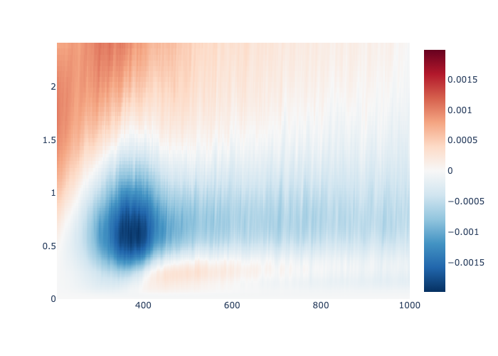

```python
# Let's plot the distribution of errors coming from the model
import pypkg.plotting
from pypkg.plotting import plot_heatmap

plot_heatmap(
    error_x,
    data,
    ix_min=600,
    iy_max=100,
    diverging=True,
    interactive=False,
)
```

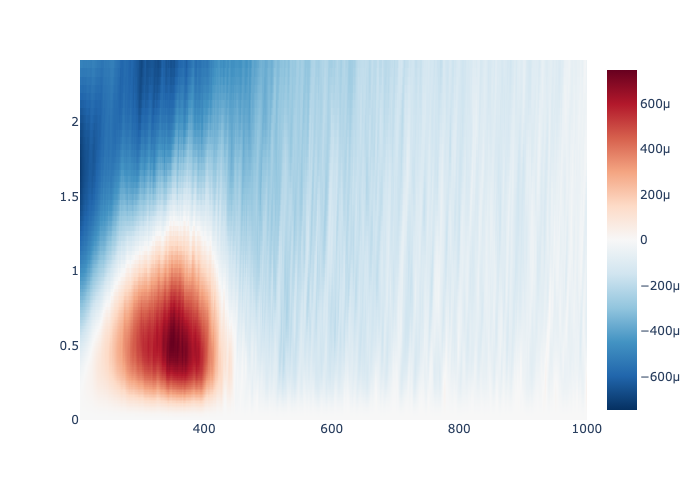

```python
plot_heatmap(
    data["dkdx"],
    data,
    ix_min=600,
    iy_max=100,
    diverging=True,
    interactive=False,
)
```

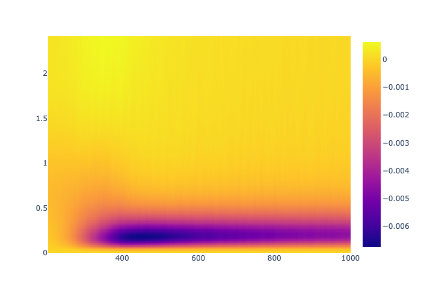

```python
plot_heatmap(
    data["duvdy"],
    data,
    ix_min=600,
    iy_max=100,
    diverging=False,
    interactive=False,
)
```

## Attempting to model the (1, 2) component of the Reynolds stress transport

From the inspections above, the cross-stream gradient of $\overline{u^\prime v^\prime}$ is the largest driver of momentum transport in the streamwise direction. Therefore, we should try to find a PDE that describes this field well, such that we can solve that and plug it back into the momentum equation.

We could use something like

$$ \left( \nabla \cdot \vec{U} \right) \mathbf{R} = a \nabla^2 \mathbf{R} + b \vec{U} \nabla P + c \nabla \vec{U} + d \vec{U} \nabla K + e \nabla P \nabla P $$

for which the (1, 2) component is

$$ U \frac{\partial \overline{u^\prime v^\prime}}{\partial x} + V \frac{\partial \overline{u^\prime v^\prime}}{\partial y} = a \left( \frac{\partial^2 \overline{u^\prime v^\prime}}{\partial x^2} + \frac{\partial^2 \overline{u^\prime v^\prime}}{\partial y^2} \right) + b U \frac{\partial P}{\partial y} + c \frac{\partial U}{\partial y} + d U \frac{\partial K}{\partial y} + e \frac{\partial P}{\partial x} \frac{\partial P}{\partial y} $$

```python
# Compute a bunch of quantities and add to the data
data = read_profiles()
dx = np.gradient(data["x"])
dy = np.reshape(np.gradient(data["y"]), (224, 1))
data["k"] = 0.5 * (data["u"] ** 2 + data["v"] ** 2)
data["dkdy"] = np.gradient(data["k"], axis=0) / dy
data["dpdx"] = np.gradient(data["p"], axis=1) / dx
data["dpdy"] = np.gradient(data["p"], axis=0) / dy
data["duvdx"] = np.gradient(data["uv"], axis=1) / dx
data["duvdy"] = np.gradient(data["uv"], axis=0) / dy
data["d2uvdx2"] = np.gradient(data["duvdx"], axis=1) / dx
data["d2uvdy2"] = np.gradient(data["duvdy"], axis=0) / dy
data["adv_uv_12"] = data["u"] * data["duvdx"] + data["v"] * data["duvdy"]
data["laplacian_uv_12"] = data["d2uvdx2"] + data["d2uvdy2"]
data["u_gradp_12"] = data["u"] * data["dpdy"]
data["u_gradk_12"] = data["u"] * data["dkdy"]
data["gradp_gradp_12"] = data["dpdx"] * data["dpdy"]
```

```python
from sklearn.linear_model import LinearRegression

terms = [
    "laplacian_uv_12",
    "u_gradp_12",
    "dudy",
    "u_gradk_12",
    # "gradp_gradp_12",
]
# Form our X matrix
X = np.array([data[term].flatten() for term in terms]).transpose()
# Form our y vector, which is the advection term for uv
y = data["adv_uv_12"].flatten()
# Fit the model
reg = LinearRegression(fit_intercept=False).fit(X, y)
# Compute the RMSE of the fit
rmse_no_model = np.sqrt(np.sum(y**2))
pred = reg.predict(X)
error = y - pred
rmse_model = np.sqrt(np.sum(error**2))
error = error.reshape((len(data["y"]), len(data["x"])))
# Print metrics
print("Score:", reg.score(X, y))
print("RMSE no model:", rmse_no_model)
print("RMSE model:", rmse_model)
print()
for term, coeff in zip(terms, reg.coef_):
    print(term, coeff)
```

```
Score: 0.15397301746463943
RMSE no model: 0.0018572481452001253
RMSE model: 0.0016119583792787357

laplacian_uv_12 4.023143641219501e-06
u_gradp_12 -0.0015131124572531388
dudy 4.361192043360582e-07
u_gradk_12 -1.717943227045777e-05
```

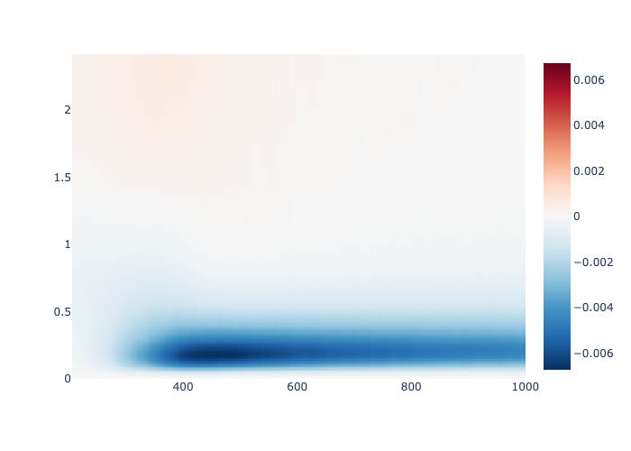

```python
plot_heatmap(
    data["duvdy"],
    data,
    ix_min=600,
    iy_max=100,
    diverging=True,
    interactive=False,
)
```

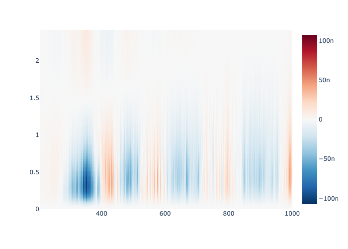

```python
plot_heatmap(
    data["gradp_gradp_12"],
    data,
    ix_min=600,
    iy_max=100,
    diverging=True,
    interactive=False,
)
```

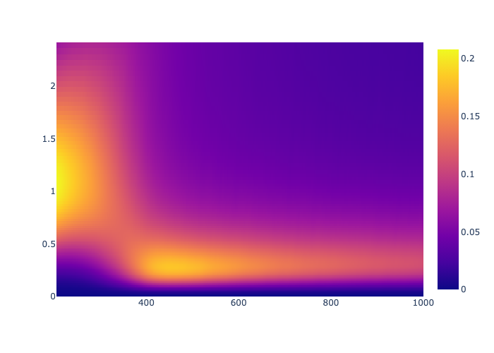

```python
plot_heatmap(
    data["u_gradk_12"],
    data,
    ix_min=600,
    iy_max=100,
    diverging=False,
    interactive=False,
)
```

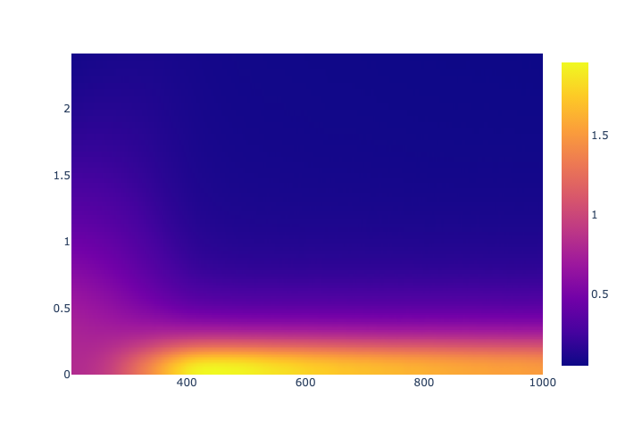

```python
plot_heatmap(
    data["dudy"],
    data,
    ix_min=600,
    iy_max=100,
    diverging=False,
    interactive=False,
)
```